# Reproducible Research: Peer Assessment 1

## Loading and preprocessing the data

Take in activity data csv and convert string date to POSIXct format

Here is the code for this step:

```r
## Load csv
activity_rawdata <- read.csv(file = "activity.csv", stringsAsFactors = F)

## Change date from string to date class
date_converted <- strptime(activity_rawdata$date, format = "%Y-%m-%d")

## combine with raw data for our activity set to use
activity_processed <- cbind(activity_rawdata, date_converted)
```

## What is mean total number of steps taken per day?

In this code total steps per day is calculated and a histogram is created showing the data

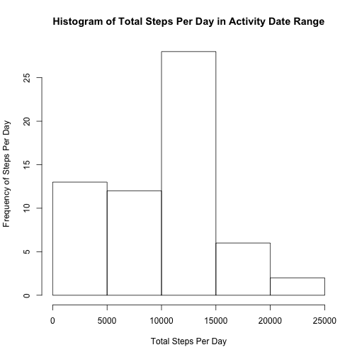

```r
## sum each days steps - counting NA as 0
sum_steps_per_day <- aggregate(activity_processed$steps, list(activity_processed$date_converted),
    FUN = sum, na.rm = T)

hist(sum_steps_per_day$x, main = "Histogram of Total Steps Per Day in Activity Date Range",
    xlab = "Total Steps Per Day", ylab = "Frequency of Steps Per Day")
```

In this code the mean and median total number of steps taken per day is calculated and displayed

```r
## take the mean and median and ready for output
mean_steps <- mean(sum_steps_per_day$x)
median_steps <- median(sum_steps_per_day$x)
cbind(mean_steps, median_steps)
```

```
##      mean_steps median_steps
## [1,]       9354        10395
```

## What is the average daily activity pattern?

Here we aggregate the average steps taken over the date range by the interval and show a time series plot

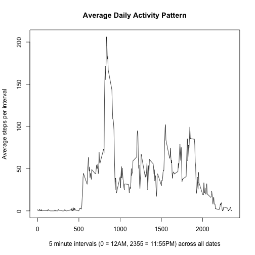

```r
average_steps_by_interval <- aggregate(activity_processed$steps, list(activity_processed$interval),
    FUN = mean, na.rm = T)
plot(average_steps_by_interval$Group.1, average_steps_by_interval$x, type = "l",
    xlab = "5 minute intervals (0 = 12AM, 2355 = 11:55PM) across all dates",
    ylab = "Average steps per interval", main = "Average Daily Activity Pattern")
```

To see on average across all the days in the dataset, which interval contains the maximum number of steps we run this code

```r
average_steps_by_interval[max(average_steps_by_interval$x) == average_steps_by_interval$x,
    ]
```

```
##     Group.1     x
## 104     835 206.2
```

This shows that the interval that has the maximum number of steps is 8:35 AM

## Imputing missing values

First we calculate how many NA values there are in our data

```r
sum(!complete.cases(activity_processed))
```

```
## [1] 2304
```

Then we replace the NA values using the average 5 minute interval across ALL days we calculated before - this is put into a new dataset

```r
## make a copy
activity_processed_nona <- activity_processed

## update copy from other dataset when na
activity_processed_nona$steps <- ifelse(is.na(activity_processed_nona$steps),
    average_steps_by_interval$x[match(activity_processed_nona$interval, average_steps_by_interval$Group.1)],
    activity_processed_nona$steps)
```

In this code total steps per day is calculated and a histogram is created showing the data

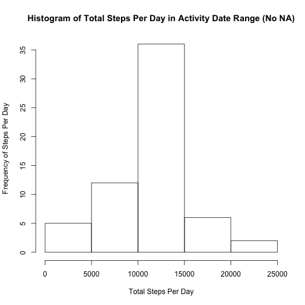

```r
## sum each days steps - counting NA as 0
sum_steps_per_day_nona <- aggregate(activity_processed_nona$steps, list(activity_processed_nona$date_converted),
    FUN = sum, na.rm = F)

hist(sum_steps_per_day_nona$x, main = "Histogram of Total Steps Per Day in Activity Date Range (No NA)",
    xlab = "Total Steps Per Day", ylab = "Frequency of Steps Per Day")
```

In this code the mean and median total number of steps taken per day is calculated again but without NA values and displayed

```r
## take the mean and median and ready for output
mean_steps <- mean(sum_steps_per_day_nona$x)
median_steps <- median(sum_steps_per_day_nona$x)
cbind(mean_steps, median_steps)
```

```
##      mean_steps median_steps
## [1,]      10766        10766
```

The values are higher then before and are the same. This is probably because of the reused step counts from intervals.

## Are there differences in activity patterns between weekdays and weekends?

Figure out if a day is a weekend or a weekday and add a factor variable that represents that

```r
## use data that has filled in values (no NA)

activity_processed_nona <- within(activity_processed_nona, {
    weekdayfactor = as.factor(ifelse(weekdays(date_converted) %in% c("Saturday",
        "Sunday"), "weekend", "weekday"))
})
```

Now using that factor and the data show that there are some differences between activity on weekdays and weekends

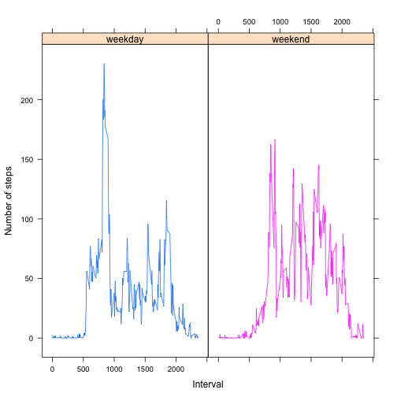

```r
## install lattice needed below if not installed
if ("lattice" %in% row.names(installed.packages()) == FALSE) {
    install.packages("lattice")
}

## pull in reshape2 library
library(lattice)

average_steps_by_interval_weekend <- aggregate(activity_processed_nona$steps,
    list(activity_processed_nona$weekdayfactor, activity_processed_nona$interval),
    FUN = mean, na.rm = F)

xyplot(x ~ Group.2 | Group.1, average_steps_by_interval_weekend, groups = Group.1,
    type = "l", xlab = "Interval", ylab = "Number of steps")
```

Here is to waking up later on the weekend and not walking as much early in the morning!